# 1_balanced_data

## Importar librerias y rutas

Se importan las librerias requeridas el proceso de análisis de datos y se establecen las rutas globales de los archivos.

```python
#importing libraries
from sklearn.datasets import load_boston
import pandas as pd
import numpy as np
import matplotlib
import matplotlib.pyplot as plt
import seaborn as sns
import statsmodels.api as sm
%matplotlib inline
from sklearn.model_selection import train_test_split
from sklearn.linear_model import LinearRegression
from sklearn.feature_selection import RFE
from sklearn.linear_model import RidgeCV, LassoCV, Ridge, Lasso
from root import DIR_DATA_INPUT, DIR_DATA_OUTPUT
```

```python
import glob
path_xls = '{}{}/'.format(DIR_DATA_INPUT,'views')
path_result = '{}{}/'.format(DIR_DATA_OUTPUT,'profiling')
all_files = glob.glob(path_xls + "*.xlsx")
print(all_files)
```

```
['/media/gabriel/Data/Projects/Lumon/electromuebles/data/input/views/V5_Vista_Minable.xlsx']
```

## Verificar datos perdidos contra PandasProfiling

Se leen los datos de las vistas minables iniciales y se verifica datos perdidos y categoricos y potenciales grupos. Tambien se etiqueta la varaible clase que vamos a usar.

```python
#Loading the dataset
path_dataset = '{}views/{}'.format(DIR_DATA_INPUT, 'V5_Vista_Minable.xlsx')
df_file = pd.read_excel(path_dataset, engine='openpyxl')
```

```python
X = df_file.drop("tipo_cliente", 1)   #Feature Matrix
y = df_file["tipo_cliente"]          #Target Variable
```

```python
X.head()
```

|  | Row | procedencia | genero | estado_civil | edad | municipio_residencia | municipio_nacimiento | municipio_expedicion | tiene_casa_propia | sueldo_smdlv | ... | municipio_credito | codeudor | sector | año_credito | mes_credito | valor_credito_smdlv | tipo_venta | periodo_credito | cuotas | forma_pago |
| --- | --- | --- | --- | --- | --- | --- | --- | --- | --- | --- | --- | --- | --- | --- | --- | --- | --- | --- | --- | --- | --- |
| 0 | 1 | Nacional | NaN | NaN | NaN | SARAVENA | NaN | NaN | NaN | NaN | ... | SARAVENA | SIN CODEUDOR | PRIVADO | 2020 | 12 | 356 | ELECTRODOMESTICOS | QUINCENAL(ES) | 1 | CRÉDITO |
| 1 | 2 | Nacional | NaN | NaN | NaN | ARAUQUITA | ARAUQUITA | ARAUQUITA | NaN | NaN | ... | ARAUQUITA | CON CODEUDOR | PRIVADO | 2018 | 5 | 61 | ELECTRODOMESTICOS | MENSUAL(ES) | 12 | CRÉDITO |
| 2 | 3 | Nacional | NaN | NaN | NaN | ARAUQUITA | ARAUQUITA | ARAUQUITA | NaN | NaN | ... | ARAUQUITA | CON CODEUDOR | PRIVADO | 2019 | 6 | 114 | ELECTRODOMESTICOS | MENSUAL(ES) | 12 | CRÉDITO |
| 3 | 4 | Nacional | NaN | NaN | NaN | ARAUCA | NaN | NaN | NaN | NaN | ... | SARAVENA | CON CODEUDOR | PRIVADO | 2019 | 11 | 349 | MOTOS | MENSUAL(ES) | 12 | CRÉDITO |
| 4 | 5 | Nacional | NaN | NaN | 70.0 | ARAUCA | Otros | Otros | Si | 170.0 | ... | ARAUCA | CON CODEUDOR | PRIVADO | 2020 | 7 | 49 | ELECTRODOMESTICOS | MENSUAL(ES) | 5 | CRÉDITO |

5 rows × 22 columns

```python
X.describe()
```

|  | Row | edad | sueldo_smdlv | otros_ingresos_smdlv | año_credito | mes_credito | valor_credito_smdlv | cuotas |
| --- | --- | --- | --- | --- | --- | --- | --- | --- |
| count | 184835.00000 | 77136.000000 | 73753.00000 | 5417.000000 | 184835.000000 | 184835.000000 | 184835.000000 | 184835.000000 |
| mean | 92418.00000 | 44.548071 | 103.90700 | 54.568396 | 2012.337772 | 6.882717 | 66.486017 | 5.217724 |
| std | 53357.41284 | 11.859315 | 90.78112 | 59.055561 | 5.511453 | 3.486007 | 78.398120 | 4.460752 |
| min | 1.00000 | 18.000000 | 3.00000 | 1.000000 | 1996.000000 | 1.000000 | 0.000000 | 0.000000 |
| 25% | 46209.50000 | 35.000000 | 44.00000 | 20.000000 | 2009.000000 | 4.000000 | 19.000000 | 1.000000 |
| 50% | 92418.00000 | 44.000000 | 73.00000 | 34.000000 | 2014.000000 | 7.000000 | 45.000000 | 4.000000 |
| 75% | 138626.50000 | 53.000000 | 130.00000 | 63.000000 | 2017.000000 | 10.000000 | 78.000000 | 10.000000 |
| max | 184835.00000 | 90.000000 | 600.00000 | 300.000000 | 2021.000000 | 12.000000 | 700.000000 | 14.000000 |

```python
X.dtypes
```

```
Row                       int64
procedencia              object
genero                   object
estado_civil             object
edad                    float64
municipio_residencia     object
municipio_nacimiento     object
municipio_expedicion     object
tiene_casa_propia        object
sueldo_smdlv            float64
otros_ingresos           object
otros_ingresos_smdlv    float64
municipio_credito        object
codeudor                 object
sector                   object
año_credito               int64
mes_credito               int64
valor_credito_smdlv       int64
tipo_venta               object
periodo_credito          object
cuotas                    int64
forma_pago               object
dtype: object
```

```python
def verify_values():
    # Valores Unicos
    for name_col in X.columns.tolist():
        print('-'*100)
        print('Column: ', name_col)
        print(X[name_col].unique())
        print(X[name_col].value_counts())
        print('nan_value:', X[name_col].isnull().sum())
```

## Verificar datos perdidos contra PandasProfiling

- Escalar
  - edad has 107699 (58.3%) missing values Missing
  - sueldo_smdlv has 111082 (60.1%) missing values Missing
  - otros_ingresos_smdlv has 179418 (97.1%) missing values
- Categoricas
  - genero has 97541 (52.8%) missing values Missing
  - estado_civil has 102421 (55.4%) missing values Missing
  - municipio_expedicion has 93581 (50.6%) missing values Missing

```python
from sklearn.impute import SimpleImputer, KNNImputer

# verify_values()
fields_imputer = {'edad': 'mean', 'sueldo_smdlv': 'mean', 'otros_ingresos_smdlv': 'mean', 'genero': 'most_frequent',
                  'estado_civil': 'most_frequent', 'municipio_expedicion': 'most_frequent', 'sector': 'most_frequent',
                  'municipio_nacimiento': 'most_frequent', 'tiene_casa_propia': 'most_frequent'}

for key in fields_imputer:
    print('-'*50)
    print('Column:', key)
    imputer = SimpleImputer(missing_values=np.NaN, strategy=fields_imputer[key])
    print('\t{} with nan: {}'.format(key, X[key].isna().sum()))
    X[key] = imputer.fit_transform(X[key].values.reshape(-1,1), y.values.reshape(-1,1))[:,0]
    print('\t{} with out nan: {}'.format(key, X[key].isna().sum()))
    print('\t', X[key].values[:5])
# verify_values()
# TODO: Pendiente implementar vecino mas cercano de ser necesario.
# import numpy as np
# >>> from sklearn.impute import KNNImputer
# >>> nan = np.nan
# >>> X = [[1, 2, nan], [3, 4, 3], [nan, 6, 5], [8, 8, 7]]
# >>> imputer = KNNImputer(n_neighbors=2, weights="uniform")
# >>> imputer.fit_transform(X)
```

```
--------------------------------------------------
Column: edad
	edad with nan: 0
	edad with out nan: 0
	 [44.54807094 44.54807094 44.54807094 44.54807094 70.        ]
--------------------------------------------------
Column: sueldo_smdlv
	sueldo_smdlv with nan: 0
	sueldo_smdlv with out nan: 0
	 [103.90700039 103.90700039 103.90700039 103.90700039 170.        ]
--------------------------------------------------
Column: otros_ingresos_smdlv
	otros_ingresos_smdlv with nan: 0
	otros_ingresos_smdlv with out nan: 0
	 [54.56839579 54.56839579 54.56839579 54.56839579 54.56839579]
--------------------------------------------------
Column: genero
	genero with nan: 0
	genero with out nan: 0
	 ['Femenino' 'Femenino' 'Femenino' 'Femenino' 'Femenino']
--------------------------------------------------
Column: estado_civil
	estado_civil with nan: 0
	estado_civil with out nan: 0
	 ['Union Libre' 'Union Libre' 'Union Libre' 'Union Libre' 'Union Libre']
--------------------------------------------------
Column: municipio_expedicion
	municipio_expedicion with nan: 0
	municipio_expedicion with out nan: 0
	 ['ARAUCA' 'ARAUQUITA' 'ARAUQUITA' 'ARAUCA' 'Otros']
--------------------------------------------------
Column: sector
	sector with nan: 18
	sector with out nan: 0
	 ['PRIVADO' 'PRIVADO' 'PRIVADO' 'PRIVADO' 'PRIVADO']
--------------------------------------------------
Column: municipio_nacimiento
	municipio_nacimiento with nan: 0
	municipio_nacimiento with out nan: 0
	 ['ARAUCA' 'ARAUQUITA' 'ARAUQUITA' 'ARAUCA' 'Otros']
--------------------------------------------------
Column: tiene_casa_propia
	tiene_casa_propia with nan: 0
	tiene_casa_propia with out nan: 0
	 ['Si' 'Si' 'Si' 'Si' 'Si']
```

```python
obj_df = X.select_dtypes(include=['object']).copy()
obj_df.head()
obj_df.dtypes
```

```
procedencia             object
genero                  object
estado_civil            object
municipio_residencia    object
municipio_nacimiento    object
municipio_expedicion    object
tiene_casa_propia       object
otros_ingresos          object
municipio_credito       object
codeudor                object
sector                  object
tipo_venta              object
periodo_credito         object
forma_pago              object
dtype: object
```

### Verificamos valores de datos categoricos y nulos

Datos nulos para imputación de datos y codificación de los mismos

```python
# Valores Unicos
# verify_values()
for name_col in obj_df.columns.tolist():
    print('-'*100)
    print('Column: ', name_col)
    print(obj_df[name_col].unique())
    print(obj_df[name_col].value_counts())
    print('nan_value:', obj_df[name_col].isnull().sum())
```

```
----------------------------------------------------------------------------------------------------
Column:  procedencia
['Nacional' 'Extranjero']
Nacional      184680
Extranjero       155
Name: procedencia, dtype: int64
nan_value: 0
----------------------------------------------------------------------------------------------------
Column:  genero
['Femenino' 'Masculino']
Femenino     144475
Masculino     40360
Name: genero, dtype: int64
nan_value: 0
----------------------------------------------------------------------------------------------------
Column:  estado_civil
['Union Libre' 'Soltero' 'Casado' 'Divorciado' 'Viudo']
Union Libre    134605
Casado          24804
Soltero         24147
Viudo             810
Divorciado        469
Name: estado_civil, dtype: int64
nan_value: 0
----------------------------------------------------------------------------------------------------
Column:  municipio_residencia
['SARAVENA' 'ARAUQUITA' 'ARAUCA' 'TAME' 'Otros']
ARAUCA       74877
TAME         56768
SARAVENA     29913
Otros        12457
ARAUQUITA    10820
Name: municipio_residencia, dtype: int64
nan_value: 0
----------------------------------------------------------------------------------------------------
Column:  municipio_nacimiento
['ARAUCA' 'ARAUQUITA' 'Otros' 'SARAVENA' 'TAME']
ARAUCA       118507
Otros         32605
TAME          18923
```

[output cut: 61 more lines]

```
Column:  periodo_credito
['QUINCENAL(ES)' 'MENSUAL(ES)' 'DIARIA(S)' 'SEMANAL(ES)']
MENSUAL(ES)      172628
DIARIA(S)          9833
SEMANAL(ES)        1758
QUINCENAL(ES)       616
Name: periodo_credito, dtype: int64
nan_value: 0
----------------------------------------------------------------------------------------------------
Column:  forma_pago
['CRÉDITO' 'LIBRANZA']
CRÉDITO     178980
LIBRANZA      5855
Name: forma_pago, dtype: int64
nan_value: 0
```

## Codificación de datos categoricos

Aquí se convierten las clases en valores numericos

```python
from sklearn.preprocessing import OrdinalEncoder, LabelEncoder, OneHotEncoder
ord_enc = OrdinalEncoder()
one_enc = OneHotEncoder()
for name_col in obj_df.columns.tolist():
    print('-'*100)
    num_class = len(X[name_col].unique())
    print('Column: ', name_col, ' Num Class:', num_class)
    if num_class == 2:
        X[name_col+'_code'] = ord_enc.fit_transform(X[[name_col]])
    else:
        X[name_col+'_code'] = ord_enc.fit_transform(X[[name_col]])

# from sklearn.preprocessing import OrdinalEncoder, LabelEncoder, OneHotEncoder
# ord_enc = OrdinalEncoder()
# obj_df["make_code"] = ord_enc.fit_transform(obj_df[["make"]])
# obj_df[["make", "make_code"]].head(11)
```

[output not shown]

[output cut: 16 more lines]

[output not shown]

```python
print(X.head())
```

### Verificamos valores de datos categoricos y nulos

Datos nulos para imputación de datos y codificación de los mismos

```python
# Valores Unicos
# for name_col in obj_df.columns.tolist():
#     print('-'*100)
#     print('Column: ', name_col)
#     print(obj_df[name_col].unique())
#     print(obj_df[name_col].value_counts())
#     print('nan_value:', obj_df[name_col].isnull().sum())
```

## Codificación de datos categoricos

Aquí se convierten las clases en valores numericos

```python
# from sklearn.preprocessing import OrdinalEncoder, LabelEncoder, OneHotEncoder
# ord_enc = OrdinalEncoder()
# one_enc = OneHotEncoder()
# for name_col in obj_df.columns.tolist():
#     print('-'*100)
#     num_class = len(X[name_col].unique())
#     print('Column: ', name_col, ' Num Class:', num_class)
#     if num_class == 2:
#         X[name_col+'_code'] = one_enc.fit_transform(X[[name_col]])
#     else:
#         X[name_col+'_code'] = ord_enc.fit_transform(X[[name_col]])
#
# print(X.head())
# # from sklearn.preprocessing import OrdinalEncoder, LabelEncoder, OneHotEncoder
# # ord_enc = OrdinalEncoder()
# # obj_df["make_code"] = ord_enc.fit_transform(obj_df[["make"]])
# # obj_df[["make", "make_code"]].head(11)
```

[output not shown]

## Variables Dumis

```python
columns_raw = ['procedencia', 'genero', 'estado_civil', 'municipio_residencia', 'municipio_nacimiento', 'municipio_expedicion',
'tiene_casa_propia', 'otros_ingresos', 'municipio_credito', 'codeudor', 'sector', 'tipo_venta', 'periodo_credito', \
'forma_pago']
prefix_raw = ['procedencia', 'genero', 'estado_civil', 'municipio_residencia', 'municipio_nacimiento', 'municipio_expedicion',
'tiene_casa_propia', 'otros_ingresos', 'municipio_credito', 'codeudor', 'sector', 'tipo_venta', 'periodo_credito', \
'forma_pago']
cat_result = pd.get_dummies(obj_df, columns=columns_raw, prefix=prefix_raw).head()
cat_result
```

[output not shown]

[output not shown]

[output cut: 35 more lines]

```python
result_df = pd.concat([df_file, cat_result], axis=1)
```

[output not shown]

[output cut: 28 more lines]

```python
X_df = pd.concat([X, y], axis=1)
print(X_df.columns)
```

```
Index(['Row', 'procedencia', 'genero', 'estado_civil', 'edad',
       'municipio_residencia', 'municipio_nacimiento', 'municipio_expedicion',
       'tiene_casa_propia', 'sueldo_smdlv', 'otros_ingresos',
       'otros_ingresos_smdlv', 'municipio_credito', 'codeudor', 'sector',
       'año_credito', 'mes_credito', 'valor_credito_smdlv', 'tipo_venta',
       'periodo_credito', 'cuotas', 'forma_pago', 'procedencia_code',
       'genero_code', 'estado_civil_code', 'municipio_residencia_code',
       'municipio_nacimiento_code', 'municipio_expedicion_code',
       'tiene_casa_propia_code', 'otros_ingresos_code',
       'municipio_credito_code', 'codeudor_code', 'sector_code',
       'tipo_venta_code', 'periodo_credito_code', 'forma_pago_code',
       'tipo_cliente'],
      dtype='object')
```

```python
# Import the necessary libraries first
from sklearn.feature_selection import SelectKBest
from sklearn.feature_selection import chi2
```

[output not shown]

[output cut: 21 more lines]

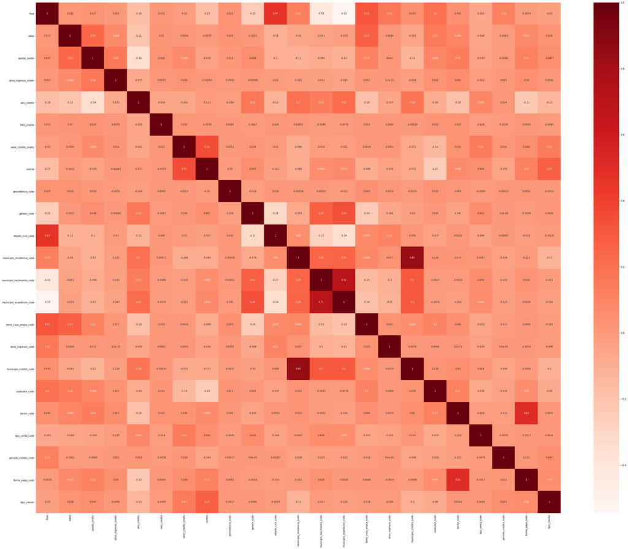

```python
# X_integration = pd.concat(X, y)

#Using Pearson Correlation
plt.figure(figsize=(50,40))
cor = X_df.corr()
sns.heatmap(cor, annot=True, cmap=plt.cm.Reds)
plt.show()
```

```python
#Correlation with output variable
cor_target = abs(cor["tipo_cliente"])
#Selecting highly correlated features
relevant_features = cor_target[cor_target>0.03]
relevant_features
```

```
sueldo_smdlv                 0.047439
año_credito                  0.132988
valor_credito_smdlv          0.137605
cuotas                       0.273039
municipio_residencia_code    0.110901
municipio_credito_code       0.102962
codeudor_code                0.080342
periodo_credito_code         0.046917
forma_pago_code              0.059804
tipo_cliente                 1.000000
Name: tipo_cliente, dtype: float64
```

```python
X_vm = X.select_dtypes(exclude=['object']).copy()
```

```python
#Splitting the data into Training and Test datafrom sklearn.model_selection import train_test_split
X_train, X_test, y_train, y_test = train_test_split(X_vm, y, test_size = 0.30, random_state = 101)#Creating the prediction model
from sklearn.linear_model import LogisticRegression
log_model = LogisticRegression(max_iter = 1000)
log_model.fit(X_train, y_train)#Performance Check
from sklearn.metrics import classification_report, confusion_matrix, roc_curve,auc, accuracy_score
predictions = log_model.predict(X_test)
print(accuracy_score(y_test, predictions))
print(classification_report(y_test,predictions))
```

```
0.5892950532902923
              precision    recall  f1-score   support

           1       0.61      0.49      0.54     21047
           2       0.00      0.00      0.00      4711
           3       0.58      0.79      0.67     28473
           4       0.01      0.00      0.00      1220

    accuracy                           0.59     55451
   macro avg       0.30      0.32      0.30     55451
weighted avg       0.53      0.59      0.55     55451
```

```python
from imblearn import FunctionSampler  # to use a idendity sampler
from imblearn.over_sampling import SMOTE, ADASYN, RandomOverSampler
from collections import Counter

X_vm = X.select_dtypes(exclude=['object']).copy()
print(Counter(y))
# define oversampling strategy
oversample = RandomOverSampler(sampling_strategy='minority')
# fit and apply the transform
X_over, y_over = oversample.fit_resample(X_vm, y)
# summarize class distribution
print(Counter(y_over))
```

```
Counter({3: 94856, 1: 70297, 2: 15662, 4: 4020})
Counter({3: 94856, 4: 94856, 1: 70297, 2: 15662})
```

```python
X_train, X_test, y_train, y_test = train_test_split(X_over, y_over , test_size = 0.30, random_state = 101)#Creating the prediction model
from sklearn.linear_model import LogisticRegression
log_model = LogisticRegression(max_iter = 1000)
log_model.fit(X_train, y_train)#Performance Check
from sklearn.metrics import classification_report, confusion_matrix, roc_curve,auc, accuracy_score
predictions = log_model.predict(X_test)
print(accuracy_score(y_test, predictions))
print(classification_report(y_test,predictions))
```

```
0.4526976373001862
              precision    recall  f1-score   support

           1       0.45      0.13      0.20     21081
           2       0.27      0.00      0.01      4703
           3       0.44      0.55      0.49     28514
           4       0.46      0.67      0.55     28404

    accuracy                           0.45     82702
   macro avg       0.41      0.34      0.31     82702
weighted avg       0.44      0.45      0.41     82702
```

```python
from imblearn import FunctionSampler  # to use a idendity sampler
from imblearn.over_sampling import SMOTE, ADASYN, RandomOverSampler
from collections import Counter

X_vm = X.select_dtypes(exclude=['object']).copy()
print(Counter(y))
# define oversampling strategy
oversample = SMOTE()
# fit and apply the transform
X_over, y_over = oversample.fit_resample(X_vm, y)
# summarize class distribution
print(Counter(y_over))

X_train, X_test, y_train, y_test = train_test_split(X_over, y_over , test_size = 0.30, random_state = 101)#Creating the prediction model
from sklearn.linear_model import LogisticRegression
log_model = LogisticRegression(max_iter = 1000)
log_model.fit(X_train, y_train)#Performance Check
from sklearn.metrics import classification_report, confusion_matrix, roc_curve,auc, accuracy_score
predictions = log_model.predict(X_test)
print(accuracy_score(y_test, predictions))
print(classification_report(y_test,predictions))
```

```
Counter({3: 94856, 1: 70297, 2: 15662, 4: 4020})
Counter({1: 94856, 3: 94856, 2: 94856, 4: 94856})
0.3686351337105106
              precision    recall  f1-score   support

           1       0.38      0.51      0.43     28346
           2       0.40      0.24      0.30     28579
           3       0.31      0.21      0.25     28427
           4       0.38      0.51      0.43     28476

    accuracy                           0.37    113828
   macro avg       0.37      0.37      0.36    113828
weighted avg       0.37      0.37      0.35    113828
```

```python
#Creating the ROC-AUC plot
preds = log_model.predict_proba(X_test)[:,1]
# fpr, tpr, threshold = roc_curve(y_test, preds)
fpr, tpr, thresholds = roc_curve(y_test, preds, pos_label='2')
roc_auc = auc(fpr, tpr)
plt.figure(figsize=(10,8))
plt.title('Receiver Operator Characteristic')
plt.plot(fpr, tpr, 'b', label = 'AUC = {}'.format(round(roc_auc, 2)))
plt.legend(loc = 'lower right')
plt.plot([0,1], [0,1], 'r--')
plt.xlim([0,1])
plt.ylim([0,1])
plt.ylabel('True Positive Rate')
plt.xlabel('False Positive Rate')
plt.show()
```

[output not shown]